# Project Kalayaan 2 - 100 MW Wind Farm

Probabilistic & Economic Selection of Step-up Transformers

Author

Jorge Thomas

Published

December 13, 2023

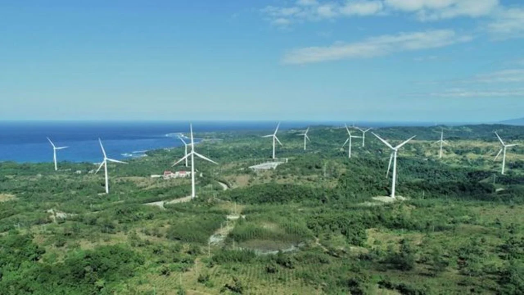

Credit: Siemens Gamesa

Figure 1: The Balaoi & Caunayan Wind Farm is an 160 MW onshore project located in the province of Ilocos Norte, Philippines.

# On-Site Wind Profile

On June the 30<sup>th</sup> of 2021 began the measuring campaign for collecting on-site wind speed and other important weather-related variables with a 10-min step resolution.

There are 61 variables named:

```
 [1] "F1_WS_120_A_330_TFCA"       "F1_WS_120_A_330_TFCA_STDev"
 [3] "F1_WS_120_A_330_TFCA_Min"   "F1_WS_120_A_330_TFCA_Max"
 [5] "F1_WS_120_A_330_TFCA_TI30"  "F2_WS_120_B_150_TFCA"
 [7] "F2_WS_120_B_150_TFCA_STDev" "F2_WS_120_B_150_TFCA_Min"
 [9] "F2_WS_120_B_150_TFCA_Max"   "F2_WS_120_B_150_TFCA_TI30"
[11] "F3_WS_100_A_330_TFCA"       "F3_WS_100_A_330_TFCA_STDev"
[13] "F3_WS_100_A_330_TFCA_Min"   "F3_WS_100_A_330_TFCA_Max"
[15] "F4_WS_100_B_150_TFCA"       "F4_WS_100_B_150_TFCA_STDev"
[17] "F4_WS_100_B_150_TFCA_Min"   "F4_WS_100_B_150_TFCA_Max"
[19] "F5_WS_60_A_330_TFCA"        "F5_WS_60_A_330_TFCA_STDev"
[21] "F5_WS_60_A_330_TFCA_Min"    "F5_WS_60_A_330_TFCA_Max"
[23] "F6_WS_60_B_150_TFCA"        "F6_WS_60_B_150_TFCA_STDev"
[25] "F6_WS_60_B_150_TFCA_Min"    "F6_WS_60_B_150_TFCA_Max"
[27] "F7_PR_7_0_K611PB"           "F7_PR_7_0_K611PB_STDev"
[29] "F7_PR_7_0_K611PB_Min"       "F7_PR_7_0_K611PB_Max"
```

[output cut: 16 more lines]

`Speed120msyn`, `Speed110msyn` and `WS120mCompFILLED120mSyn` seem to be created.

Abbreviations of the original sensor data indicate the following:

- WS: Wind Speed [m/s]
- PR: Pressure [mbar]
- WD: Wind Direction [°]
- RH: Relative Humidity [%]
- TEM: Ambient Temperature [°C]

## Check Data Integrity: Missing Values

| Variable | NA_count | Percent |
| --- | --- | --- |
| A2_WD_97_150_0_5V | 48245 | 52.42 |
| A2_WD_97_150_0_5V_STDev | 48245 | 52.42 |
| A2_WD_97_150_0_5V_Min | 48245 | 52.42 |
| A2_WD_97_150_0_5V_Max | 48245 | 52.42 |
| F2_WS_120_B_150_TFCA_TI30 | 45123 | 49.02 |
| A4_TEM_115_0_K846TH | 31850 | 34.60 |
| A4_TEM_115_0_K846TH_STDev | 31850 | 34.60 |
| A4_TEM_115_0_K846TH_Min | 31850 | 34.60 |
| A4_TEM_115_0_K846TH_Max | 31850 | 34.60 |
| A5_RH_115_0_K846TH | 31015 | 33.70 |
| A5_RH_115_0_K846TH_STDev | 31015 | 33.70 |
| A5_RH_115_0_K846TH_Min | 31015 | 33.70 |
| A5_RH_115_0_K846TH_Max | 31015 | 33.70 |
| A6_TEM_7_0_K846TH | 30837 | 33.50 |
| A6_TEM_7_0_K846TH_STDev | 30837 | 33.50 |
| A6_TEM_7_0_K846TH_Min | 30837 | 33.50 |
| A6_TEM_7_0_K846TH_Max | 30837 | 33.50 |
| A1_WD_117_150_0_5V | 24979 | 27.14 |
| A1_WD_117_150_0_5V_STDev | 24979 | 27.14 |
| A1_WD_117_150_0_5V_Min | 24979 | 27.14 |
| A1_WD_117_150_0_5V_Max | 24979 | 27.14 |
| F1_WS_120_A_330_TFCA | 20188 | 21.93 |
| F1_WS_120_A_330_TFCA_STDev | 20188 | 21.93 |
| F1_WS_120_A_330_TFCA_Min | 20188 | 21.93 |
| F1_WS_120_A_330_TFCA_Max | 20188 | 21.93 |
| F4_WS_100_B_150_TFCA | 18169 | 19.74 |
| F4_WS_100_B_150_TFCA_STDev | 18169 | 19.74 |
| F4_WS_100_B_150_TFCA_Min | 18169 | 19.74 |
| F4_WS_100_B_150_TFCA_Max | 18169 | 19.74 |
| F3_WS_100_A_330_TFCA | 17005 | 18.48 |
| F3_WS_100_A_330_TFCA_STDev | 17005 | 18.48 |
| F3_WS_100_A_330_TFCA_Min | 17005 | 18.48 |
| F3_WS_100_A_330_TFCA_Max | 17005 | 18.48 |
| F5_WS_60_A_330_TFCA | 12308 | 13.37 |
| F5_WS_60_A_330_TFCA_STDev | 12308 | 13.37 |
| F5_WS_60_A_330_TFCA_Min | 12308 | 13.37 |
| F5_WS_60_A_330_TFCA_Max | 12308 | 13.37 |
| F7_PR_7_0_K611PB | 8884 | 9.65 |
| F7_PR_7_0_K611PB_STDev | 8884 | 9.65 |
| F7_PR_7_0_K611PB_Min | 8884 | 9.65 |
| F7_PR_7_0_K611PB_Max | 8884 | 9.65 |
| F2_WS_120_B_150_TFCA | 6515 | 7.08 |
| F2_WS_120_B_150_TFCA_STDev | 6515 | 7.08 |
| F2_WS_120_B_150_TFCA_Min | 6515 | 7.08 |
| F2_WS_120_B_150_TFCA_Max | 6515 | 7.08 |
| F6_WS_60_B_150_TFCA | 1172 | 1.27 |
| F6_WS_60_B_150_TFCA_STDev | 1172 | 1.27 |
| F6_WS_60_B_150_TFCA_Min | 1172 | 1.27 |
| F6_WS_60_B_150_TFCA_Max | 1172 | 1.27 |
| Speed120msyn | 1075 | 1.17 |
| A7_RH_7_0_K846TH | 1057 | 1.15 |
| A7_RH_7_0_K846TH_STDev | 1057 | 1.15 |
| A7_RH_7_0_K846TH_Min | 1057 | 1.15 |
| A7_RH_7_0_K846TH_Max | 1057 | 1.15 |
| Speed110msyn | 752 | 0.82 |
| WS120mCompFILLED120mSyn | 752 | 0.82 |
| A3_WD_57_150_0_5V | 732 | 0.80 |
| A3_WD_57_150_0_5V_STDev | 732 | 0.80 |
| A3_WD_57_150_0_5V_Min | 732 | 0.80 |
| A3_WD_57_150_0_5V_Max | 732 | 0.80 |
| F1_WS_120_A_330_TFCA_TI30 | 231 | 0.25 |

This means that the best measurement of wind speed for the total **air parcel** is the Avg. of all sensors installed at different heights.

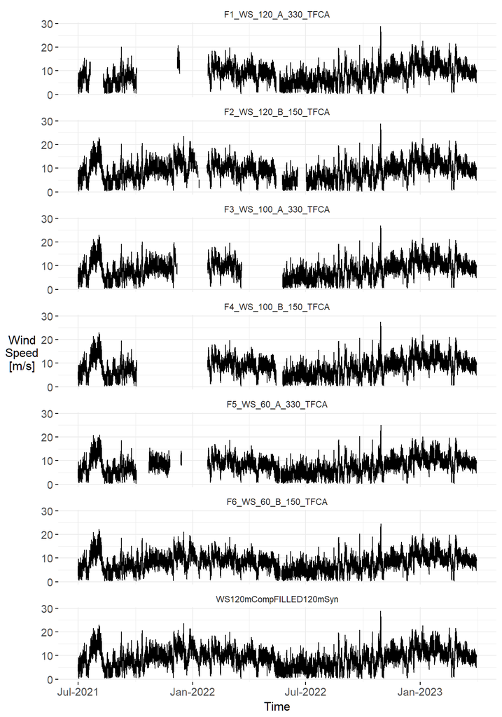

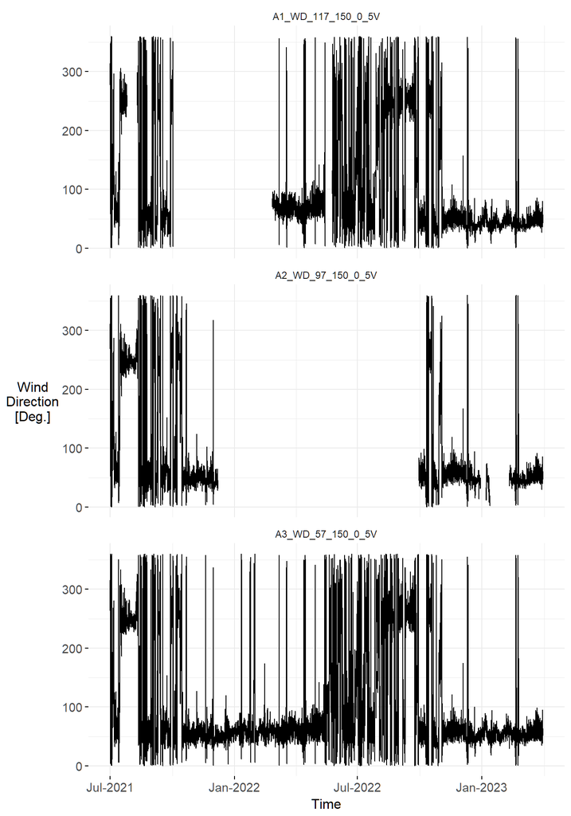

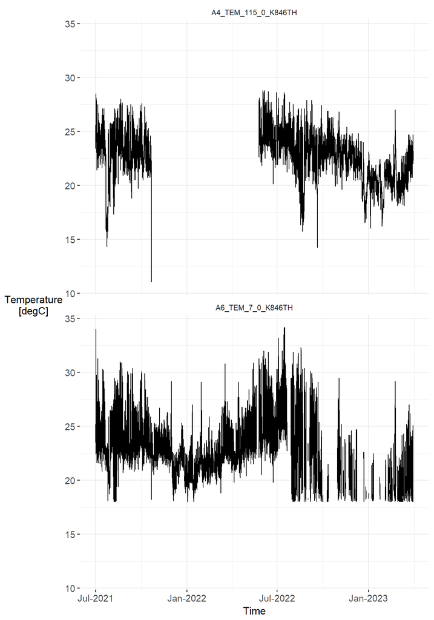

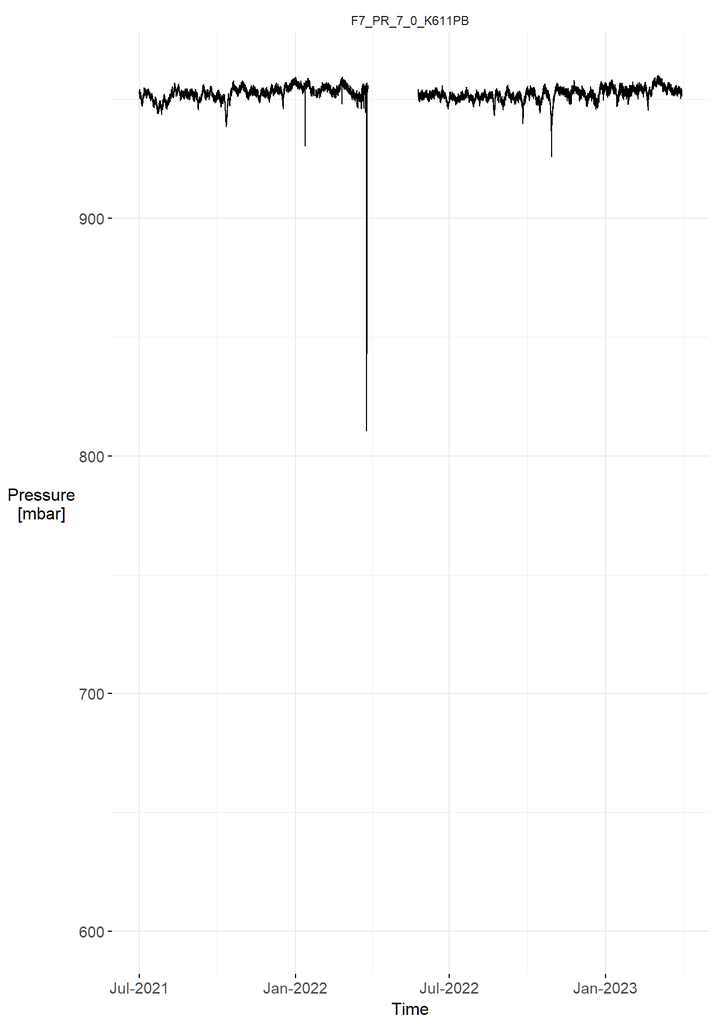

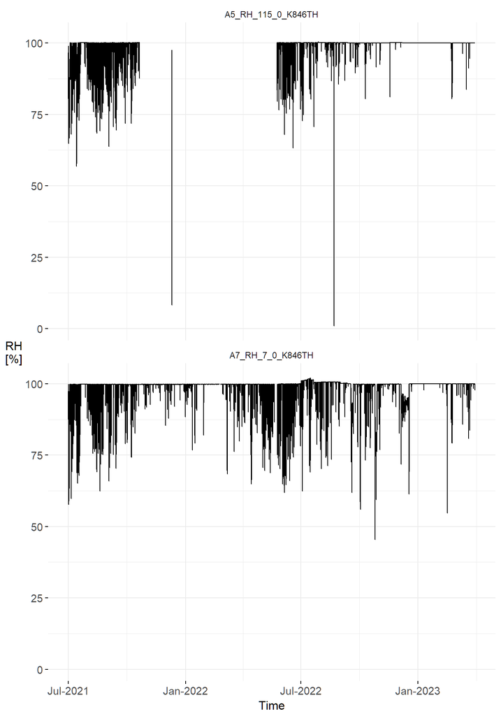

It’s important to keep all units within the **SI**, therefore I will convert the following units:

- PR: Pressure [mbar] –> [Pa]
- TEM: Ambient Temperature [°C] –> [K]

```
Rows: 92,041
Columns: 8
$ A4_TEM_115_0_K846TH       <dbl> 298.75, 298.55, 298.55, 298.45, 298.55, 298.…
$ A4_TEM_115_0_K846TH_STDev <dbl> 273.45, 273.45, 273.45, 273.45, 273.45, 273.…
$ A4_TEM_115_0_K846TH_Min   <dbl> 298.45, 298.45, 298.35, 298.35, 298.45, 298.…
$ A4_TEM_115_0_K846TH_Max   <dbl> 299.95, 299.95, 299.85, 299.85, 299.85, 299.…
$ A6_TEM_7_0_K846TH         <dbl> 298.25, 298.25, 298.05, 298.05, 297.95, 297.…
$ A6_TEM_7_0_K846TH_STDev   <dbl> 273.25, 273.15, 273.25, 273.25, 273.15, 273.…
$ A6_TEM_7_0_K846TH_Min     <dbl> 298.05, 298.05, 297.95, 297.95, 297.95, 297.…
$ A6_TEM_7_0_K846TH_Max     <dbl> 298.35, 298.35, 298.35, 298.25, 298.25, 298.…
```

**Temperature** $(T)$, **pressure** $(p)$ and **relative humidity** $(\phi)$ are important to calculate the **humid air density**[^1] $(\rho_h)$, which affects the output power $P_{out}$ of wind turbines; lower density means lower power output.

${\rho_h={\frac{p_d}{R_{d}T}} + {\frac{p_v}{R_{v}T}}={\frac {p_{\text{d}}M_d+p_{v}M_{v}}{RT}}}$

R, universal gas constant, 8.31446 J/(K·mol)

${p_{v}=\phi p_{sat}}$

where:

${p_{v}}$, vapor pressure of water

$\phi$, relative humidity (0.0–1.0)

$p_{sat}$, saturation vapor pressure

Tetens equation to calculate the saturation vapour pressure of water over liquid https://en.wikipedia.org/wiki/Tetens_equation

${p_{sat} = 6.1078\times \exp({\frac {17.5T}{T+237.3}})}$

The partial pressure of dry air

${p_{d}}$ is found considering partial pressure, resulting in:

${p_{d}=p-p_{v}}$

where

$p$ simply denotes the observed absolute pressure.

## Wind Turbine Output Power

$P_{out} = C_p \frac{1}{2} \rho A v^3$

## Footnotes

[^1]: The more water vapour in the air, the less is its total density; this seems counter-intuitive.